# DSC5103 Assignment 5

#### 3b. Plot the variable importance, find out the partial dependency on variables *MaxHR*, *Thal*, and the two variables *Age* and *Chol* jointly. Briefly interpret the plots. (1 Mark)

Answer:

```r
# variable importance
importance_matrix <- xgb.importance(model = optimal.xgb, feature_names = colnames(x.train))
importance_matrix
```

```
##                 Feature         Gain        Cover    Frequency
##  1:             Oldpeak 1.676222e-01 1.465470e-01 1.341753e-01
##  2:               MaxHR 1.666336e-01 1.443673e-01 1.383553e-01
##  3:                 Age 1.202305e-01 1.393999e-01 1.538895e-01
##  4:      Thalreversable 1.061784e-01 8.239942e-02 6.272975e-02
##  5:              RestBP 8.312099e-02 9.689325e-02 1.056860e-01
##  6:          Thalnormal 8.212823e-02 5.104926e-02 4.099964e-02
##  7:                Chol 6.760152e-02 9.153602e-02 1.122080e-01
##  8:              Slope2 4.631498e-02 4.883159e-02 4.651370e-02
##  9:                 Ca1 3.789554e-02 4.854092e-02 4.820349e-02
## 10: ChestPainnonanginal 3.579563e-02 4.274502e-02 4.245227e-02
## 11:              ExAng1 2.511100e-02 2.717083e-02 2.451678e-02
## 12:                Sex1 2.251881e-02 3.149511e-02 3.696786e-02
## 13:                 Ca2 2.085885e-02 2.548878e-02 2.324203e-02
## 14:            RestECG2 1.453814e-02 1.840404e-02 2.416103e-02
## 15:                Fbs1 1.875124e-03 2.556348e-03 2.757026e-03
## 16: ChestPainnontypical 1.343321e-03 2.181779e-03 2.727381e-03
## 17:              Slope3 1.529577e-04 2.327472e-04 2.668090e-04
## 18:                 Ca3 5.716055e-05 1.076659e-04 8.893632e-05
## 19:    ChestPaintypical 2.307480e-05 5.300643e-05 5.929088e-05
```

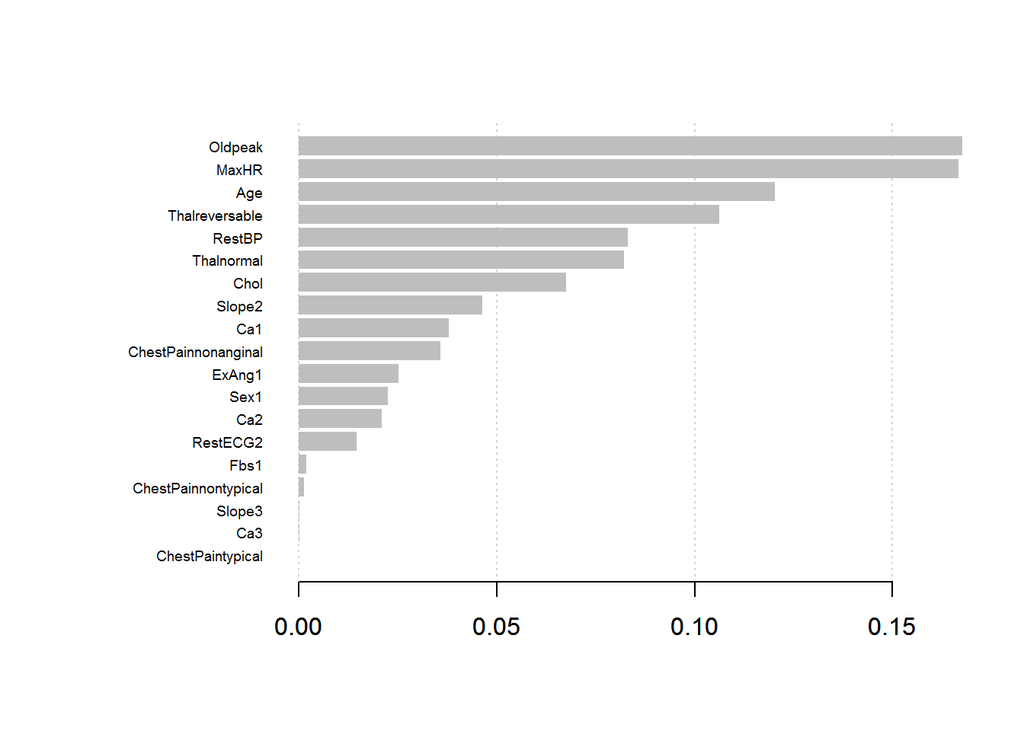

```r
xgb.plot.importance(importance_matrix=importance_matrix)
```

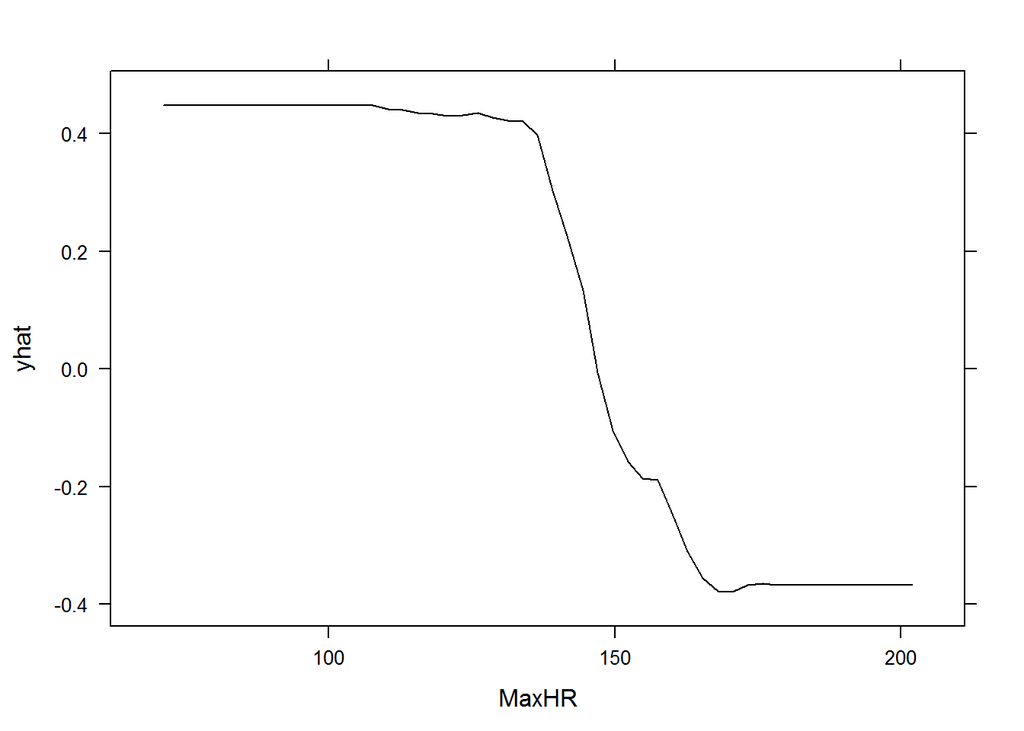

```r
library(pdp)
library(ggplot2)
pd1 <- partial(optimal.xgb, train=x.train, pred.var = "MaxHR", chull = TRUE)
# plot using lattice
plotPartial(pd1)
```

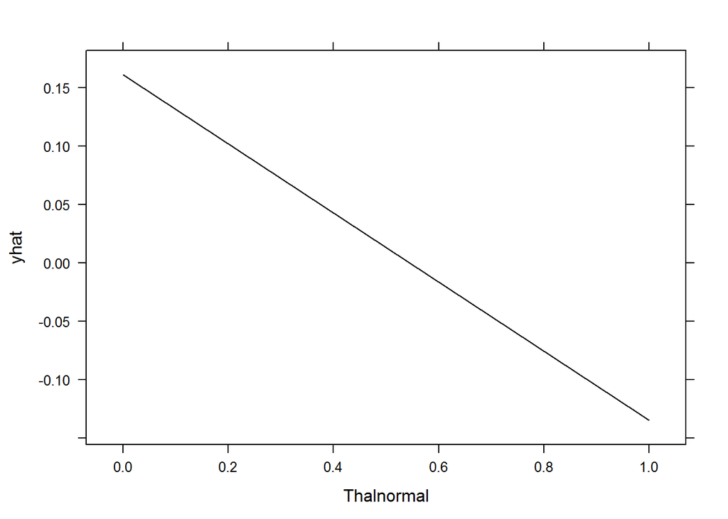

```r
pd2 <- partial(optimal.xgb, train=x.train, pred.var = "Thalnormal", chull = TRUE)
plotPartial(pd2)
```

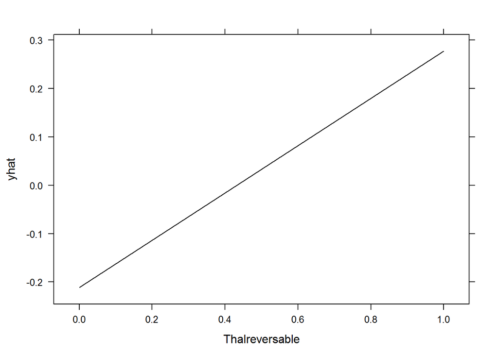

```r
pd3 <- partial(optimal.xgb, train=x.train, pred.var = "Thalreversable", chull = TRUE)
plotPartial(pd3)
```

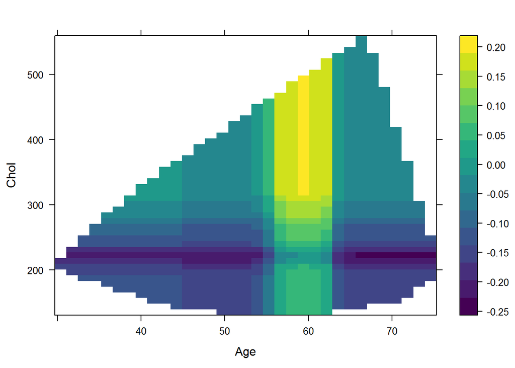

```r
# 2-D partial plot
pd4 <- partial(optimal.xgb, train=x.train, pred.var = c("Age", "Chol"), chull=TRUE)

plotPartial(pd4)
```

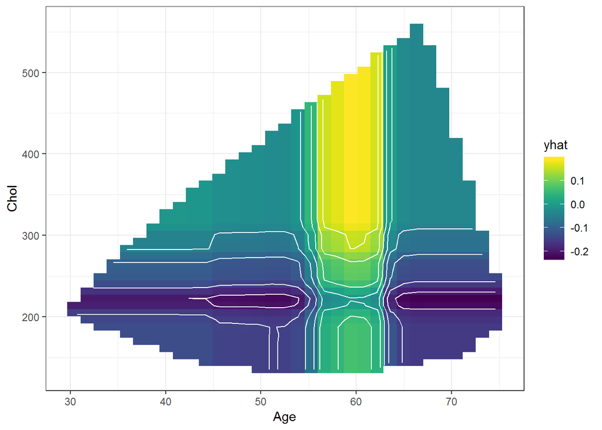

```r
autoplot(pd4, contour = TRUE)
```

Discussion:

#### 4. Compare the above-studied model predictions in terms of misclassification rate and AUC. (1 Mark)

Answer:

```r
library(ROCR)
# Misclassification error
tree.prediction <- prediction(tree.pred[,2], heart[test.index, "AHD"])
rf.prediction <- prediction(yhat.rf[,2], heart[test.index, "AHD"])
xgb.prediction <- prediction(xgb.pred, heart[test.index, "AHD"])
tree.err <- performance(tree.prediction, measure = "err")
rf.err <- performance(rf.prediction, measure = "err")
xgb.err <- performance(xgb.prediction, measure = "err")

# AUC
as.numeric(performance(tree.prediction, "auc")@y.values)
```

[output not shown]

```
## [1] 0.7727941
```

```r
as.numeric(performance(rf.prediction, "auc")@y.values)
```

```
## [1] 0.9959559
```

```r
as.numeric(performance(xgb.prediction, "auc")@y.values)
```

```
## [1] 0.8544118
```

#### 5. [OPTIONAL] Try to mix the predictions we have here and we had from Assignment 4 and construct an ensemble prediction that performs better.